# Practical info

This workshop is organised by the **National Bioinformatics Infrastructure, Sweden (NBIS)** and sponsored by the **Science for Life Laboratory (SciLifeLab) & Wallenberg National Program for [Data-Driven Life Science](https://www.scilifelab.se/data-driven/) (DDLS)**. [NBIS](https://nbis.se) is a platform of the Science for Life Laboratory ([SciLifeLab](https://www.scilifelab.se/)).

If you would like to get in touch with us regarding this workshop, please contact us at **edu.population-genomics-in-practice [at] nbis.se** or **edu.pgip [at] nbis.se**.

## Organizers

[Per Unneberg](https://nbis.se/about/staff)

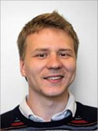

[Nikolay Oskolkov](https://nbis.se/about/staff)

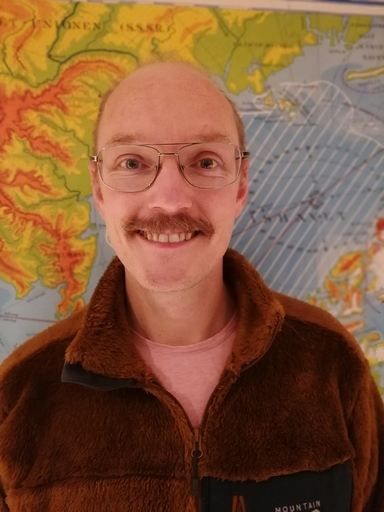

[Jason Hill](https://nbis.se/about/staff)

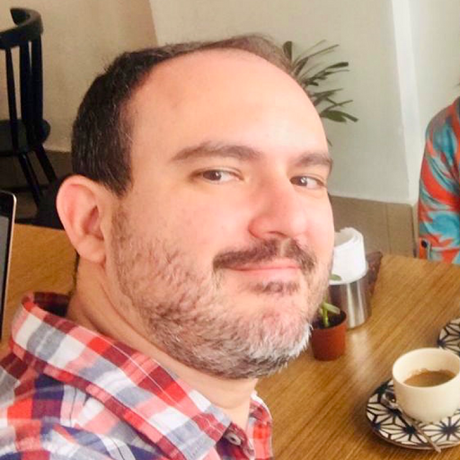

[André Soares](https://nbis.se/about/staff)

## Venue

The workshop is held onsite in [Trippelrummet](https://www.bmc.uu.se/scilifelab-navet-inglish/meeting-rooms-in-navet/#anchor-933950) in [Navet](https://www.bmc.uu.se/scilifelab-navet-inglish/) at the [Uppsala Biomedical Centre](https://www.bmc.uu.se/), Uppsala.

**Location**

##### Uppsala

[interactive chart not shown]

Room [E10:1309](https://link.mazemap.com/Wza07nfx)  
Entrance C11  
Biomedicinskt centrum  
Uppsala University / ScilifeLab  
Husargatan 3  
75237 Uppsala  
Sweden

Some selected hotels are listed below ranked by distance from the venue.

- [Hotel von Kraemer](https://hotelvonkraemer.se/) (900 m, 11 min walk)
- [Akademihotellet](https://akademihotellet.se/en/) (1.7 Km, 21 min walk)
- [CityStay Hotell](https://citystayuppsala.se/) (1.8 Km, 21 min walk)
- [Grand Hotel Hörnan](https://www.grandhotellhornan.com/) (1.9 Km, 23 min walk)
- [Hotell Centralstation](http://hotellcentralstation.se/) (2.1 Km, 25 min walk)
- [Best Western Svava](https://www.hotelsvava.se/) (2.2 Km, 26 min walk)

The venue and hotels are also marked on the map.

Use the [UL website](https://www.ul.se) or the [UL app](https://www.ul.se/en/tickets/how-to-buy-a-ticket/the-UL-app/) for bus and train services around Uppsala. For buses from the Centralstation (Train/Bus), take Bus 4 (towards **Gottsunda Centrum**) or 8 (towards **Sunnersta**) and get off at the stop **Uppsala Science Park**. Bus tickets can be purchased in the app or directly from the driver using a credit card.